# Building R Packages Using fakemake

Andreas Dominik Cullmann

2020-12-21, 20:51:02

**There’s a more elaborated vignette coming with package `packager`. Please see [packager’s vignette](https://cran.r-project.org/package=packager/vignettes/An_Introduction_to_packager.html).**

## Creating the Package

First, we need to create a sample package, so we create a package skeleton:

```r
pkg_path <- file.path(tempdir(), "fakepack")
unlink(pkg_path, force = TRUE, recursive = TRUE)
usethis::create_package(pkg_path)
```

And add a minimal R code file:

```r
file.copy(system.file("templates", "throw.R", package = "fakemake"),
          file.path(pkg_path, "R"))
```

```
## [1] TRUE
```

This package does not make any sense. It is just a minimal working example (in the sense that it passes `R CMD build` and a simple `R CMD check`). It does not provide any functionality apart from a single internal function that is not exported via the package’s NAMESPACE. It is just there to exemplify the usage of *fakemake*.

## Setting Up the Makelist

Then we get a package makelist:

```r
ml <-  fakemake::provide_make_list("vignette")
```

And we have a look at it:

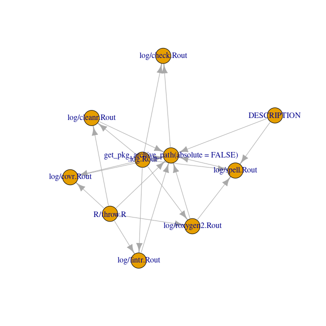

```r
withr::with_dir(pkg_path, fakemake::visualize(ml))
```

Obviously the tarball depends on many files and the only target that’s no other target’s prerequisite is “log/check.Rout”. If you are more into hierarchical depictions, you can use the terminal target as root:

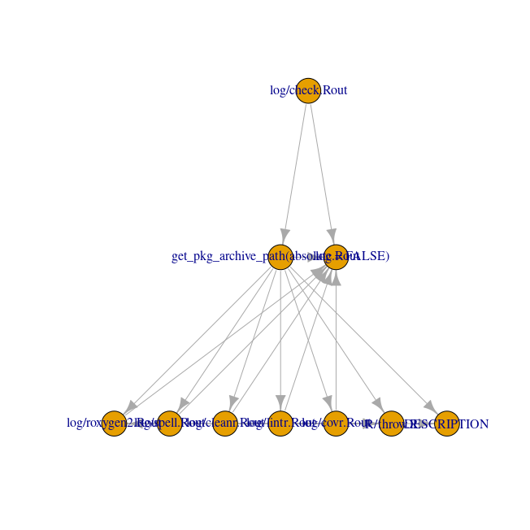

```r
withr::with_dir(pkg_path, fakemake::visualize(ml, root = "log/check.Rout"))
```

But then you might be interested in [this python program](https://github.com/lindenb/makefile2graph), it would leave with this graph:

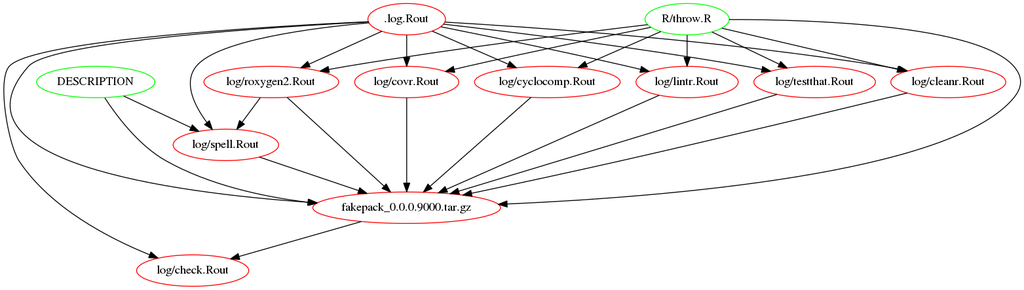

I regularly use it to visualize complex Makefiles.

### More on Target Rules

Let’s take a look at the target rule that builds the tarball:

```r
index <- which(sapply(ml, function(x) x["alias"] == "build"))
ml[[index]]
```

```
## $alias
## [1] "build"
##
## $target
## [1] "get_pkg_archive_path(absolute = FALSE)"
##
## $code
## [1] "print(pkgbuild::build(path = \".\", dest_path = \".\", vignettes = FALSE))"
##
## $sink
## [1] "log/build.Rout"
##
## $prerequisites
## [1] ".log.Rout"
## [2] "list.files(\"R\", full.names = TRUE, recursive = TRUE)"
## [3] "list.files(\"man\", full.names = TRUE, recursive = TRUE)"
## [4] "DESCRIPTION"
## [5] "file.path(\"log\", \"lintr.Rout\")"
## [6] "file.path(\"log\", \"cleanr.Rout\")"
## [7] "file.path(\"log\", \"spell.Rout\")"
## [8] "file.path(\"log\", \"covr.Rout\")"
## [9] "file.path(\"log\", \"roxygen2.Rout\")"
```

Note that some of its items are strings giving file names, some are strings that parse as R expressions, and `prerequisites` is a mix of both. Obviously, *fakemake* parses and evaluates these character strings dynamically.

Let us take a look at the prerequisites for `roxygen2`:

```r
index <- which(sapply(ml, function(x) x["alias"] == "roxygen2"))
ml[[index]][["prerequisites"]]
```

```
## [1] ".log.Rout"
## [2] "list.files(\"R\", full.names = TRUE, recursive = TRUE)"
```

## Building the Package

Now we build and check the package in one go:

```r
withr::with_dir(pkg_path, print(fakemake::make("check", ml)))
```

```
## [1] ".log.Rout"
## [2] "log/cleanr.Rout"
## [3] "log/covr.Rout"
## [4] "log/lintr.Rout"
## [5] "log/roxygen2.Rout"
## [6] "log/spell.Rout"
## [7] "get_pkg_archive_path(absolute = FALSE)"
## [8] "log/check.Rout"
```

We should now detach the package to prevent the coverage target to crash in subsequent calls.

```r
if ("fakepack" %in% .packages()) detach("package:fakepack", unload = TRUE)
```

We see the files created in the log directory correspond to the names given by *make*:

```r
list.files(file.path(pkg_path, "log"))
```

```
## [1] "build.Rout"    "check.Rout"    "cleanr.Rout"   "covr.Rout"
## [5] "lintr.Rout"    "roxygen2.Rout" "spell.Rout"
```

and we can take a look at one:

```r
cat(readLines(file.path(pkg_path, "log", "check.Rout")), sep = "\n")
```

```
## * using log directory ‘/tmp/RtmpK8kWr5/fakepack/fakepack.Rcheck’
## * using R Under development (unstable) (2022-03-31 r82044)
## * using platform: x86_64-pc-linux-gnu (64-bit)
## * using session charset: UTF-8
## * using option ‘--as-cran’
## * checking for file ‘fakepack/DESCRIPTION’ ... OK
## * this is package ‘fakepack’ version ‘0.0.0.9000’
## * package encoding: UTF-8
## * checking CRAN incoming feasibility ... NOTE
## Maintainer: ‘First Last <first.last@example.com>’
##
## New submission
##
## Version contains large components (0.0.0.9000)
##
## Non-FOSS package license (`use_mit_license()`, `use_gpl3_license()` or friends to pick a
## license)
##
## DESCRIPTION fields with placeholder content:
##   Title: what the package does (one line, title case)
##   Description: what the package does (one paragraph).
## * checking package namespace information ... OK
## * checking package dependencies ... OK
## * checking if this is a source package ... OK
## * checking if there is a namespace ... OK
## * checking for executable files ... OK
## * checking for hidden files and directories ... NOTE
## Found the following hidden files and directories:
##   .log.Rout
## These were most likely included in error. See section ‘Package
## structure’ in the ‘Writing R Extensions’ manual.
##
## CRAN-pack does not know about
##   .log.Rout
## * checking for portable file names ... OK
## * checking for sufficient/correct file permissions ... OK
## * checking serialization versions ... OK
## * checking whether package ‘fakepack’ can be installed ... OK
## * checking installed package size ... OK
## * checking package directory ... OK
```

[output cut: 30 more lines]

```
## * checking for missing documentation entries ... OK
## * checking for code/documentation mismatches ... OK
## * checking Rd \usage sections ... OK
## * checking Rd contents ... OK
## * checking for unstated dependencies in examples ... OK
## * checking examples ... OK
## * checking PDF version of manual ... OK
## * checking for non-standard things in the check directory ... OK
## * checking for detritus in the temp directory ... OK
## * DONE
## Status: 1 WARNING, 2 NOTEs
##
## See
##   ‘/tmp/RtmpK8kWr5/fakepack/fakepack.Rcheck/00check.log’
## for details.
```

Rebuilding the package does not do anything (NULL is returned instead of the names of targets above), you save quite some CPU time compared to unconditionally rerunning the codes in the makelist:

```r
system.time(suppressMessages(withr::with_dir(pkg_path,
                                             print(fakemake::make("check",
                                                                  ml)))))
```

```
##    user  system elapsed
##   0.093   0.004   0.106
```

## Changing Files and Rebuilding the Package

Let us take a look at our testing coverage:

```r
cat(readLines(file.path(pkg_path, "log", "covr.Rout")), sep = "\n")
```

```
##    filename functions line value
## 1 R/throw.R     throw   18     0
## 2 R/throw.R     throw   19     0
## 3 R/throw.R     throw   20     0
## 4 R/throw.R     throw   21     0
## fakepack Coverage: 0.00%
## R/throw.R: 0.00%
```

Well, poor. So we add a test file:

```r
dir.create(file.path(pkg_path, "tests", "testthat"), recursive = TRUE)
file.copy(system.file("templates", "testthat.R", package = "fakemake"),
          file.path(pkg_path, "tests"))
```

```
## [1] TRUE
```

```r
file.copy(system.file("templates", "test-throw.R", package = "fakemake"),
          file.path(pkg_path, "tests", "testthat"))
```

```
## [1] TRUE
```

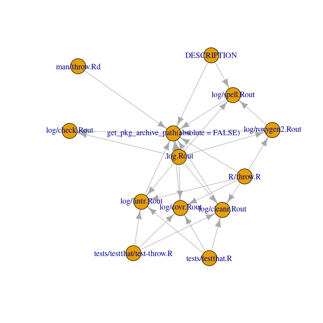

```r
withr::with_dir(pkg_path, fakemake::visualize(ml))
```

Now we re-build the package’s tarball again (of course we could `make("check", ml)` again, but for the sake of (CRAN’s) CPU time, I skip the check):

```r
withr::with_dir(pkg_path, print(fakemake::make("build", ml)))
```

```
## [1] "log/cleanr.Rout"
## [2] "log/covr.Rout"
## [3] "log/lintr.Rout"
## [4] "get_pkg_archive_path(absolute = FALSE)"
```

We see that most of the build chain is rerun, except *roxygenising*, since the files under “tests/” are not prerequisites to *log/royxgen2.Rout*. Ah, and the test coverage is improved:

```r
cat(readLines(file.path(pkg_path, "log", "covr.Rout")), sep = "\n")
```

```
## [1] filename  functions line      value
## <0 rows> (or 0-length row.names)
## fakepack Coverage: 100.00%
## R/throw.R: 100.00%
```